# Data Preprocessing Project

Yong Pui Tung

2 Jan 2024

## **Setup**

```r
library(readr)
library(dplyr)
library(magrittr)
library(outliers)
library(MVN)
library(here)
library(tidyr)
library(ggplot2)
library(kableExtra)
library(stringr)
library(splitstackshape)
library(lubridate)
library(editrules)
library(forecast)
library(ggplot2)
```

## **Executive Summary**

The five main processes of data preprocessing are “get, understand, tidy & manipulate, scan, and transform”. All procedures and the collection of tasks required to clean up all types of messy data have been accomplished.

The two data sets are imported into R using the `readr` package after being downloaded in csv format from Kaggle. After that, we remove the duplicate value that is discovered in the data set and combine the information using left join function by the shared variable between the two data sets. To understand the variables in the data set and the significance of each value, the dimensions and structure of the combined data “songs” are evaluated. Following Hadley Wickham’s “Tidy Data” principles (Wickham and Grolemund (2016)), brackets in the values of genre column are removed, and each value has been separated into its own cell. When dealing with a huge data frame, it is often preferred to focus solely on a few key variables. As a result, a new data frame named `songs_selected` is created and the data is organized based on the popularity and track name of the songs. In order to make the time data more understandable after the data has been cleaned up, we have created a new variable (`duration_min`) by mutating the original variable (`duration_ms`).

For missing values, special values, and obvious errors, we have gone through the scanning procedure. The NA value is successfully translated into “uncategorized” and no special value is discovered. We also use established rules to search for glaring mistakes. The observer outlier in the data set has been identified with the use of boxplot and z-score. We normalize the data at the last stage by using the appropriate transformations (logarithm and square root).

## **Data**

The first data set (`unpopular_songs.csv`), which contains a single sheet with the label “unpopular songs”, displays over 10,000 unpopular songs discovered on the music streaming service Spotify. The second data set (`z_genre_of_artists.csv`) contains a single sheet with the name “z genre of artists” that includes information of more than 1,700 artists with the associated genres categorized by Spotify. One song can belong to multiple categories. Both data sets’ updates is completed since August 2022, with popularity ratings ranging from 0 to 100 based on Spotify data. Notably, the dataset focuses solely on songs ranging from 0 to 18, considered as unpopular by Spotify’s rating system.

Both data sets are downloaded from Kaggle at [link1](https://www.kaggle.com/datasets/estienneggx/spotify-unpopular-songs?select=unpopular_songs.csv) and [link2](https://www.kaggle.com/datasets/estienneggx/spotify-unpopular-songs?select=z_genre_of_artists.csv)

### Import Data

The `readr` package is needed to import and read the data from the csv files that contain the data sets. For `unpopular_songs.csv` and `z_genre_of_artists.csv`, we load the data into the data frames `unpopular_songs` and `genre` respectively.

```r
# Import the two csv files and save them in separate data frames
unpopular_songs <- read_csv("unpopular_songs.csv")
genre <- read_csv("z_genre_of_artists.csv")
```

### Viewing the data sets

We begin by inspecting the initial 6 rows of both datasets. Utilizing the `head()` function, we examine the first 6 rows of each dataset.

```r
# Show the first six rows of "unpopular_songs" dataframe
head(unpopular_songs)
```

```
## # A tibble: 6 × 17
##   danceabil…¹ energy   key loudn…²  mode speec…³ acous…⁴ instr…⁵ liven…⁶ valence
##         <dbl>  <dbl> <dbl>   <dbl> <dbl>   <dbl>   <dbl>   <dbl>   <dbl>   <dbl>
## 1       0.53   0.77      4   -6.63     0  0.0389   0.284 5.01e-1   0.744   0.623
## 2       0.565  0.73      1   -6.06     1  0.073    0.365 0         0.237   0.511
## 3       0.427  0.546     4   -8.73     1  0.0849   0.539 1.52e-2   0.368   0.435
## 4       0.421  0.531     7   -5.52     1  0.0262   0.706 2.08e-4   0.11    0.383
## 5       0.537  0.804     8   -7.38     0  0.157    0.379 4.89e-4   0.323   0.543
## 6       0.71   0.621     9   -7.88     0  0.0329   0.405 1.9 e-3   0.103   0.546
## # … with 7 more variables: tempo <dbl>, duration_ms <dbl>, explicit <lgl>,
## #   popularity <dbl>, track_name <chr>, track_artist <chr>, track_id <chr>, and
## #   abbreviated variable names ¹danceability, ²loudness, ³speechiness,
## #   ⁴acousticness, ⁵instrumentalness, ⁶liveness
```

```r
# Show the first six rows of "genre" data frame
head(genre)
```

```
## # A tibble: 6 × 3
##   artist_name     artist_id              genre
##   <chr>           <chr>                  <chr>
## 1 James Reeder    5YCUdcLdAbaYZcdZrxNzjU []
## 2 Cold            0Gw3a3BkWLwsMLFbOBmo6Q ['alternative metal', 'industrial meta…
## 3 TG              7qwOsGanRCnWgty6lX05P4 []
## 4 Klaxons         2qlAMLpUyBjZgnzuFXXZXI ['alternative dance', 'alternative roc…
## 5 TG              7qwOsGanRCnWgty6lX05P4 []
## 6 Various Artists 0LyfQWJT6nXafLPZqxe9Of []
```

### Number of observations

```r
# Check the number of observations in "unpopular_songs"
unpopular_songs %>% count()
```

```
## # A tibble: 1 × 1
##       n
##   <int>
## 1 10877
```

```r
# Check the number of observations in "genre"
genre %>% count()
```

```
## # A tibble: 1 × 1
##       n
##   <int>
## 1  1736
```

The `count()` results reveal that the variables “unpopular songs” and “genre” have 10,877 and 1,736 observations respectively. In order to identify and remove duplicated observations, we use `unique ()` or `distinct()` function to check the distinct number of observations. After eliminating duplicated observations, the number of unique observations are calculated by `count()` function.

### Identify Duplicated Observation

```r
# Check the distinct number of observations in "unpopular_songs"
unpopular_songs %>% unique() %>% count()
```

```
## # A tibble: 1 × 1
##       n
##   <int>
## 1 10877
```

```r
# Check the distinct number of observations in "genre"
genre %>% distinct() %>% count()
```

```
## # A tibble: 1 × 1
##       n
##   <int>
## 1  1476
```

As the row number reduces from 1,736 to 1,476 after using `distinct()` and `count()` functions, the result reveals that “genre” data frame contains 1736 - 1476 = 260 duplicated rows.

### Remove Duplicated Rows

Therefore, we use `distinct()` function to remove duplicated rows and then save it as a new data frame called `new_genre.`

```r
new_genre <- genre %>% distinct()
```

### Merge Data

The left_join function from the `dplyr` package is used to merge two datasets (unpopular_songs and new_genre) based on the common variables “track_artist” in the first dataset and “artist_name” in the second dataset. The left join ensures that all rows from the unpopular_songs dataset are retained, and matching rows from the new_genre dataset are added, resulting in a combined dataset where information from both datasets is merged based on the specified variables. A new data frame named “songs” is created.

```r
songs <- unpopular_songs %>% left_join(new_genre, by=c("track_artist"="artist_name"))
```

## **Understand**

### Data Strucuture and Variable Type

In this part, we will inspect the data structure and variable types. Firstly, we check the dimensions of the data frame using `dim()` function.

```r
# Checking the dimensions of songs
dim(songs)
```

```
## [1] 10887    19
```

The output “10887 19” reveals that the data frame is a 10,887 by 19 data frame. It contains 10,887 rows and 19 columns.

Then we check variable types in the combined data set “songs” using `str()` function.

```r
# Checking the structure of the data
str(songs)
```

```
## spc_tbl_ [10,887 × 19] (S3: spec_tbl_df/tbl_df/tbl/data.frame)
##  $ danceability    : num [1:10887] 0.53 0.565 0.427 0.421 0.537 0.71 0.419 0.565 0.547 0.533 ...
##  $ energy          : num [1:10887] 0.77 0.73 0.546 0.531 0.804 0.621 0.821 0.624 0.56 0.785 ...
##  $ key             : num [1:10887] 4 1 4 7 8 9 11 1 0 5 ...
##  $ loudness        : num [1:10887] -6.63 -6.06 -8.73 -5.52 -7.38 ...
##  $ mode            : num [1:10887] 0 1 1 1 0 0 0 1 1 1 ...
##  $ speechiness     : num [1:10887] 0.0389 0.073 0.0849 0.0262 0.157 0.0329 0.0431 0.0351 0.051 0.0481 ...
##  $ acousticness    : num [1:10887] 0.284 0.365 0.539 0.706 0.379 0.405 0.0137 0.00442 0.551 0.591 ...
##  $ instrumentalness: num [1:10887] 0.501 0 0.0152 0.000208 0.000489 0.0019 0.00365 0.221 0.179 0 ...
##  $ liveness        : num [1:10887] 0.744 0.237 0.368 0.11 0.323 0.103 0.127 0.108 0.137 0.162 ...
##  $ valence         : num [1:10887] 0.623 0.511 0.435 0.383 0.543 0.546 0.343 0.655 0.354 0.521 ...
##  $ tempo           : num [1:10887] 120.1 130 78.3 85.1 139.9 ...
##  $ duration_ms     : num [1:10887] 225696 158093 167262 236832 239400 ...
##  $ explicit        : logi [1:10887] FALSE FALSE FALSE FALSE FALSE FALSE ...
##  $ popularity      : num [1:10887] 2 2 2 2 2 2 2 2 2 2 ...
##  $ track_name      : chr [1:10887] "No Regrets" "Wild Life" "Fangs" "Afterburner" ...
##  $ track_artist    : chr [1:10887] "James Reeder" "James Reeder" "James Reeder" "James Reeder" ...
##  $ track_id        : chr [1:10887] "6f2c4a9lNx8aowZJngv7cJ" "3fTs52jsDzSuVLsifxNKO8" "6NPafqavrv0icaIHMQnXDy" "3vGmhxveURgmlZStvo0uc1" ...
##  $ artist_id       : chr [1:10887] "5YCUdcLdAbaYZcdZrxNzjU" "5YCUdcLdAbaYZcdZrxNzjU" "5YCUdcLdAbaYZcdZrxNzjU" "5YCUdcLdAbaYZcdZrxNzjU" ...
##  $ genre           : chr [1:10887] "[]" "[]" "[]" "[]" ...
##  - attr(*, "spec")=
##   .. cols(
##   ..   danceability = col_double(),
##   ..   energy = col_double(),
##   ..   key = col_double(),
##   ..   loudness = col_double(),
##   ..   mode = col_double(),
##   ..   speechiness = col_double(),
##   ..   acousticness = col_double(),
##   ..   instrumentalness = col_double(),
##   ..   liveness = col_double(),
##   ..   valence = col_double(),
##   ..   tempo = col_double(),
##   ..   duration_ms = col_double(),
##   ..   explicit = col_logical(),
##   ..   popularity = col_double(),
##   ..   track_name = col_character(),
##   ..   track_artist = col_character(),
##   ..   track_id = col_character()
##   .. )
##  - attr(*, "problems")=<externalptr>
```

### Data Conversion

Most variables are numeric (e.g. valence, tempo, duration ms, etc). They stand for the music elements of the songs. There are units for some variables, including dB, BPM, and milliseconds. “Explicit” is a unique variable having a logic-based structure since it is captured from the original data as TRUE or FALSE. The remaining parameters (track name, track_artist, track_id, artist_id, and genre) take the data type of character.

Next, we will apply data type conversion. Popularity in this data set signifies the ranking of songs, with 0 denoting the lowest rank and 18 the highest. Therefore, we change the data type of “popularity” from numeric to ordered factor using factor() function.

```r
# Converting the data type to factor
songs$popularity <- factor(songs$popularity,
                           levels=c("0", "1", "2", "3", "4", "5", "6", "7",
                                       "8", "9", "10", "11", "12", "13", "14",
                                       "15", "16", "17", "18"),
                           ordered = TRUE)
```

We then verify whether the transformation is successful or not using `class()` function. A successful transformation is indicated by the function returning “ordered” and “factor” as the data type.

```r
class(songs$popularity)
```

```
## [1] "ordered" "factor"
```

Furthermore, we transform “mode” from numerical variable to factor. Observations in the mode column are represented by number 0 and 1. We label 0 as “major” and 1 as “minor” to avoid confusion and for easier understanding.

```r
songs$mode <- factor(songs$mode,
                     levels=c("0","1"),
                     labels=c("Major","Minor"))
```

```r
# Check the factor's level
levels(songs$mode)
```

```
## [1] "Major" "Minor"
```

### Data structure

Finally, we verify the entire data set’s structure once again using str() function.

```r
# Verify the whole data structure again
str(songs)
```

```
## spc_tbl_ [10,887 × 19] (S3: spec_tbl_df/tbl_df/tbl/data.frame)
##  $ danceability    : num [1:10887] 0.53 0.565 0.427 0.421 0.537 0.71 0.419 0.565 0.547 0.533 ...
##  $ energy          : num [1:10887] 0.77 0.73 0.546 0.531 0.804 0.621 0.821 0.624 0.56 0.785 ...
##  $ key             : num [1:10887] 4 1 4 7 8 9 11 1 0 5 ...
##  $ loudness        : num [1:10887] -6.63 -6.06 -8.73 -5.52 -7.38 ...
##  $ mode            : Factor w/ 2 levels "Major","Minor": 1 2 2 2 1 1 1 2 2 2 ...
##  $ speechiness     : num [1:10887] 0.0389 0.073 0.0849 0.0262 0.157 0.0329 0.0431 0.0351 0.051 0.0481 ...
##  $ acousticness    : num [1:10887] 0.284 0.365 0.539 0.706 0.379 0.405 0.0137 0.00442 0.551 0.591 ...
##  $ instrumentalness: num [1:10887] 0.501 0 0.0152 0.000208 0.000489 0.0019 0.00365 0.221 0.179 0 ...
##  $ liveness        : num [1:10887] 0.744 0.237 0.368 0.11 0.323 0.103 0.127 0.108 0.137 0.162 ...
##  $ valence         : num [1:10887] 0.623 0.511 0.435 0.383 0.543 0.546 0.343 0.655 0.354 0.521 ...
##  $ tempo           : num [1:10887] 120.1 130 78.3 85.1 139.9 ...
##  $ duration_ms     : num [1:10887] 225696 158093 167262 236832 239400 ...
##  $ explicit        : logi [1:10887] FALSE FALSE FALSE FALSE FALSE FALSE ...
##  $ popularity      : Ord.factor w/ 19 levels "0"<"1"<"2"<"3"<..: 3 3 3 3 3 3 3 3 3 3 ...
##  $ track_name      : chr [1:10887] "No Regrets" "Wild Life" "Fangs" "Afterburner" ...
##  $ track_artist    : chr [1:10887] "James Reeder" "James Reeder" "James Reeder" "James Reeder" ...
##  $ track_id        : chr [1:10887] "6f2c4a9lNx8aowZJngv7cJ" "3fTs52jsDzSuVLsifxNKO8" "6NPafqavrv0icaIHMQnXDy" "3vGmhxveURgmlZStvo0uc1" ...
##  $ artist_id       : chr [1:10887] "5YCUdcLdAbaYZcdZrxNzjU" "5YCUdcLdAbaYZcdZrxNzjU" "5YCUdcLdAbaYZcdZrxNzjU" "5YCUdcLdAbaYZcdZrxNzjU" ...
##  $ genre           : chr [1:10887] "[]" "[]" "[]" "[]" ...
##  - attr(*, "spec")=
##   .. cols(
##   ..   danceability = col_double(),
##   ..   energy = col_double(),
##   ..   key = col_double(),
##   ..   loudness = col_double(),
##   ..   mode = col_double(),
##   ..   speechiness = col_double(),
##   ..   acousticness = col_double(),
##   ..   instrumentalness = col_double(),
##   ..   liveness = col_double(),
##   ..   valence = col_double(),
##   ..   tempo = col_double(),
##   ..   duration_ms = col_double(),
##   ..   explicit = col_logical(),
##   ..   popularity = col_double(),
##   ..   track_name = col_character(),
##   ..   track_artist = col_character(),
##   ..   track_id = col_character()
##   .. )
##  - attr(*, "problems")=<externalptr>
```

## **Tidy & Manipulate Data I**

### Tidy Data Principles

According to Wickham and Grolemund (2016), there are three interrelated rules which make a data set tidy.

1. Each variable must have its own column.
2. Each observation must have its own row.
3. Each value must have its own cell.

For “songs” data set, it obeys the first and second rules as each variable forms its own column and each track forms its own row. However, the order of columns is not very comprehensive as the column of track name is positioned after most variables, such as `duration_ms`, `popularity`, etc. This will be tidied up at later stage.

Nonetheless, it does not obey the third rule as each value does not have its own cell when we inspect the values under `genre` column. In order to ensure a consistent form that matches the semantics of the data set with the way it is stored, we need to reshape and tidy the data using various functions.

### Tidying “genre” column

The observations must be cleaned up by removing any extra symbols or brackets, and the value order must be rearranged to ensure that each cell has just one value. First, we use the function `str_sub` to eliminate any undesired [ ] from each value in the genre column.

```r
songs$genre <- str_sub(songs$genre, start=2L, end=nchar(songs$genre)-1L)
```

After that, each value is split into its own cell and converted to long format using the `cSpilt` function. It is converted to long format as we follow Tidy Data Principle 2 that each observation must have its own row.

```r
songs_2 <- cSplit(songs, "genre", sep=",", direction="long")
```

To eliminate the unwanted ’ ’ from the value, `str_sub` function is applied.

```r
songs_2$genre <- str_sub(songs_2$genre, start=2L, end=nchar(songs_2$genre)-1L)
```

### Using select() function

When working with a large data frame, often we want to only assess specific variables. The `select()` function allows us to select variables. As `dplyr` functions will not modify inputs, we use the assignment operator to save the result as a new data set called `songs_selected`.

```r
# Select columns by name using the pipe operator and save it in a new data set
songs_selected <- songs_2 %>% select(popularity, track_name, track_artist, mode, duration_ms, genre)
```

### Using arrange() function

We then apply `arrange()` function to order the data set by popularity and track name in ascending order.

```r
# Order the data set according to two variables
songs_selected %<>% arrange(popularity, track_name)
```

### Using filter() function

We filter out songs with popularity equal to 0 and compile them into a new data frame called `unpopular_genre` to identify the most unpopular songs within their respective genres. Some songs are not categorized, which contain the value NA. We use `drop_na()` to drop any null values.

```r
# Select songs with 0 popularity, then group them by genre
unpopular_genre <- songs_selected %>% filter(popularity == "0") %>% group_by(genre) %>%
  summarise(number_of_most_unpopular_songs = n())

# Arrange them by descending order
unpopular_genre %>% arrange(desc(number_of_most_unpopular_songs)) %>% drop_na()
```

```
## # A tibble: 268 × 2
##    genre            number_of_most_unpopular_songs
##    <chr>                                     <int>
##  1 sleep                                       120
##  2 water                                        74
##  3 environmental                                64
##  4 gangster rap                                 51
##  5 sound                                        49
##  6 houston rap                                  43
##  7 rap                                          41
##  8 southern hip hop                             41
##  9 latin pop                                    35
## 10 dirty south rap                              34
## # … with 258 more rows
```

## **Tidy & Manipulate Data II**

After tidying the data, we would like to mutate two new variables from the existing variable duration_ms for easier understanding of the time data. Currently the duration is in millisecond, but we would like to change the unit to second and minute. Here we will use `seconds_to_period()` function from `lubridate` package to handle time data.

As the original data set provides the time data in millisecond, we will first divide duration_ms by 1000 first before applying `seconds_to_period()` function.

### Using seconds_to_period() function

```r
# Use seconds_to_period function to transform duration_ms
songlength <- seconds_to_period(songs_selected$duration_ms/1000)

# Checking if the transformation is successful
head(songlength)
```

```
## [1] "5M 10.497S"           "4M 1.62700000000001S" "28.16S"
## [4] "28.16S"               "28.16S"               "28.16S"
```

```r
# Check the class of songlength
class(songlength)
```

```
## [1] "Period"
## attr(,"package")
## [1] "lubridate"
```

### Using mutate() function

We add one new variable using `mutate()` function from `dplyr` package.

```r
# Create new variables "duration_min"
# Then drop the existing variable "duration_ms"
songs_selected %<>%
  mutate(songs_selected, duration_min = round(songlength)) %>%
  select (-duration_ms)
```

Then we check if the new variable has been successfully added to the data frame.

```r
# Checking the class of songlength
glimpse(songs_selected)
```

```
## Rows: 11,384
## Columns: 6
## $ popularity   <ord> 0, 0, 0, 0, 0, 0, 0, 0, 0, 0, 0, 0, 0, 0, 0, 0, 0, 0, 0, …
## $ track_name   <chr> "\"Caro Nome che il mio cor\" From Rigoletto", "\"Til I C…
## $ track_artist <chr> "Ileana Cotrubas", "London Philharmonic Orchestra", "Swis…
## $ mode         <fct> Minor, Minor, Minor, Minor, Minor, Minor, Minor, Minor, M…
## $ genre        <chr> NA, NA, "chopped and screwed", "dirty south rap", "dirty …
## $ duration_min <Period> 5M 10S, 4M 2S, 28S, 28S, 28S, 28S, 28S, 28S, 2M 21S, 3…
```

## **Scan I**

In this part, we will scan the data for missing values, special values, and obvious errors. Firstly, we find if there is any missing values.

### Scanning for Missing Values

As we read the data from two csv files, any missing value will be represented as NA for integer, < NA > for character variable. To identify missing values in the data frame, we can use `is.na()` function coupled with `colSums()` function to find the total missing values in each column in our data frame.

```r
# Identify total number of NAs in each column
colSums(is.na(songs_selected))
```

```
##   popularity   track_name track_artist         mode        genre duration_min
##            0            0            0            0          951            0
```

We found that column “genre” has 951 NA values. As it is not numeric, we cannot recode the missing value using normal subsetting and assignment operations. The best way is to use `replace_na()` function from `tidyr` package to replace NA values. As NA means that the song is not categorized, we can replace NAs with character “uncategorized” for a better understanding.

```r
# Replace NA values in "genre"
songs_selected$genre <- replace_na(songs_selected$genre, "uncategorized")

# Check total number of NAs in each column again to confirm there is no missing value in the data frame
colSums(is.na(songs_selected))
```

```
##   popularity   track_name track_artist         mode        genre duration_min
##            0            0            0            0            0            0
```

### Scanning for Special Values

After dealing with missing values, we will check if there is any special value, i.e. -Inf, Inf and NaN. We can use `is.finite`, `is.infinite`, or `is.nan` functions to identify the special values in a data set. As we are checking the entire data frame, we need to use apply family functions. We use `sapply` function here. It can be applied to a list. As data frames possess the characteristics of both lists and matrices, `sapply` can be applied to data frames.

We create a new function to check for the sum of infinite or NaN or NA values for numerical column, and the sum of NA values for other columns. We write the function inside `sapply()` and calculate the total missing values for each column.

```r
# Check every numerical column whether they have infinite or NaN or NA values using a function
sapply(songs_selected, function(x) {
  if(is.numeric(x)) {sum(is.infinite(x) | is.nan(x) | is.na(x))}
  else {sum(is.na(x))}
    })
```

```
##   popularity   track_name track_artist         mode        genre duration_min
##            0            0            0            0            0            0
```

From the result, there is no missing value or special value.

### Scanning for Obvious Error

Next, we will check if there is any obvious inconsistency that may not correspond to a real-world situation. For example, a song duration can not be negative.

We will define a restriction on the duration_min variable using `editset` functions from `editrules` package.

```r
(Rule1 <- editset("duration_min > 0"))
```

```
##
## Edit set:
## num1 : 0 < duration_min
```

The `editset` function parses the textual rules and stores them in an editset object. The data set can be checked against these rules using the violatedEdits function. If there is data which violates the rules, it will return a logical array of “TRUE”. Here we will check the total sum.

```r
violatedEdits(Rule1, songs_selected) %>% sum()
```

```
## [1] 0
```

The result “0” means that there is no data violating the rule, hence returning all “FALSE” and therefore no “TRUE” is returned.

## **Scan II**

As missing values, special values, and obvious errors have been defined and managed, we will now scan for outliers.

### Using boxplot() function

According to Tukey’s method of outlier detection, outliers are the values in the data set that are out of the outlier fences, which is a pair of limitations calculated in between −1.5×IQR to 1.5×IQR range of the boxplot.

Given that, we begin with using `boxplot()` function to get the boxplot of the duration_min variable, which has previously been applied with `period_to_seconds()` function to approximately convert the variable into seconds.

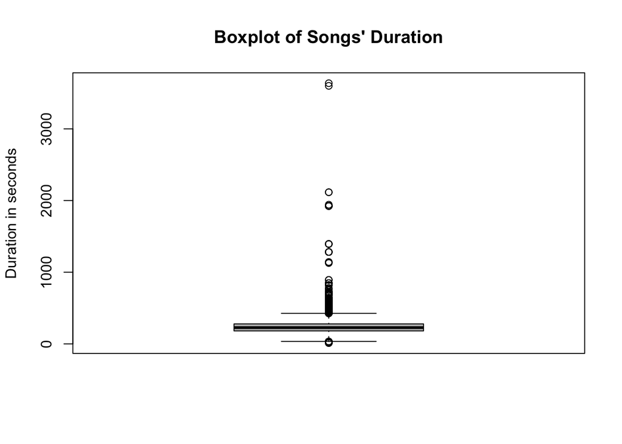

```r
songs_selected$duration_min %>% period_to_seconds() %>% boxplot(main="Boxplot of Songs' Duration", ylab="Duration in seconds", col = "grey")
```

According to the Tukey’s method, the duration variable seems to have many outliers.

### Using z-score

In order to find how many outliers there are, we will be looking at the z-score using `score()` function from outliers package. First, we will have to ensure if our distribution is approximately normal. For this, we apply `hist()` function to see the histogram.

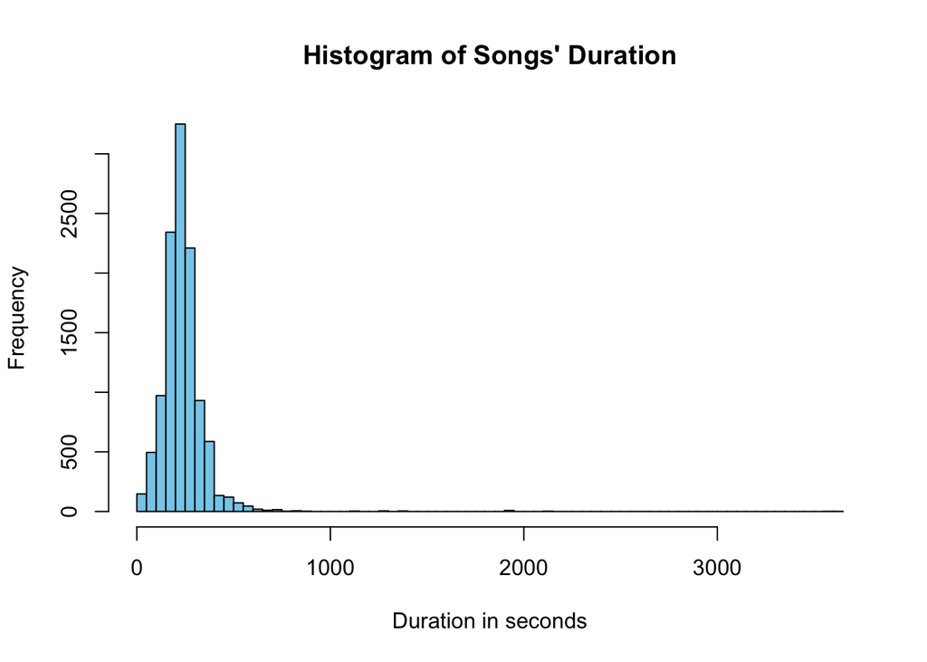

```r
songs_selected$duration_min %>% period_to_seconds() %>% hist(main="Histogram of Songs' Duration", xlab="Duration in seconds", breaks=100, col="skyblue")
```

The histogram is right skewed due to obvious outliers longer than 1000 seconds.

We now calculate z-score for our data using `score()` function.

```r
z.scores <- songs_selected$duration_min %>% period_to_seconds() %>% scores(type = "z")
z.scores %>% summary()
```

```
##     Min.  1st Qu.   Median     Mean  3rd Qu.     Max.
## -1.88659 -0.47167 -0.08654  0.00000  0.34882 28.46304
```

Using summary() function, we find that the mean is close to zero, indicating that the dataset has a relatively balanced distribution around the mean. However, the presence of a very large maximum value (28.46304) suggests the presence of potential outliers that significantly affect the overall range of the data.

Lastly, we apply `which()` function to see the locations of absolute z-score values that are greater than three and count how many they are using length() function. A z-score greater than three (in absolute value) is often considered an indicator of an outlier.

```r
which(abs(z.scores) >3 )
```

```
##  [1]    23   465   724  1781  1782  2321  3012  3013  3014  3603  4097  5170
## [13]  5734  6457  6458  6459  6460  6461  6462  6463  6464  6618  6624  6666
## [25]  6691  6853  6956  7135  7136  7137  7138  7139  7140  7141  7840  7925
## [37]  7972  7998  8010  8540  9034  9488  9489  9490  9491  9862  9863  9864
## [49]  9865 10096 10097 10098 10099 10100 10101 10102 10206 10207 10208 10209
## [61] 10476 10477 10478 10479 10480 10802 10803 10804 10811 10812 10813 10814
## [73] 10815 10816 10817 10833 10834 10835 10836 10837 11215 11314
```

```r
length (which(abs(z.scores) >3 ))
```

```
## [1] 82
```

There are 82 outliers in the dataset.

## **Transform**

From the histogram we achieved previously, we can also apply data transformation using mathematical operations to adjust the illustration of the distribution.

### Using sqrt() and log10() functions

Because of the right skewness, we apply `sqrt()` function that helps reducing right skewness or `log10()` function to compresses high values and spreads low values by expressing the values as orders of magnitude (Box, George EP, and David R Cox., 1964)

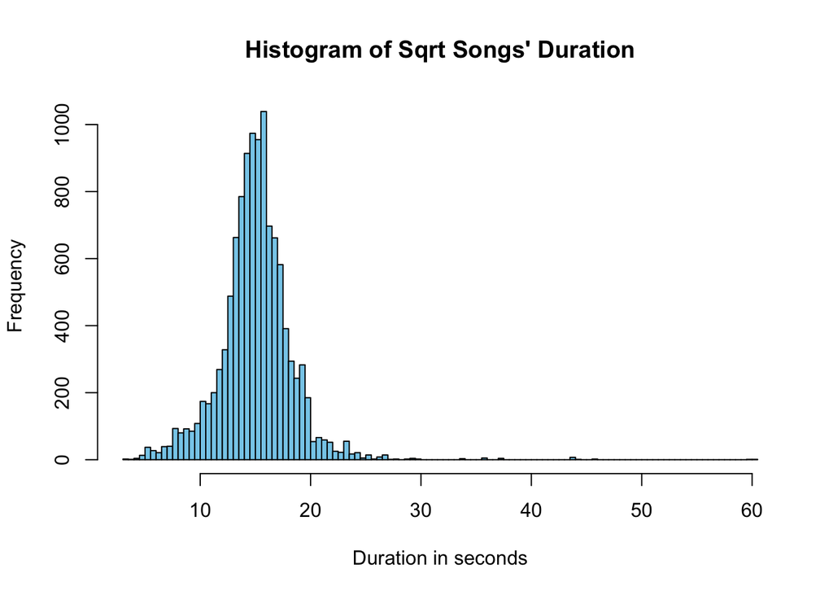

```r
songs_selected$duration_min %>% period_to_seconds() %>% sqrt() %>%
   hist(main="Histogram of Sqrt Songs' Duration", xlab="Duration in seconds", breaks=100, col="skyblue")
```

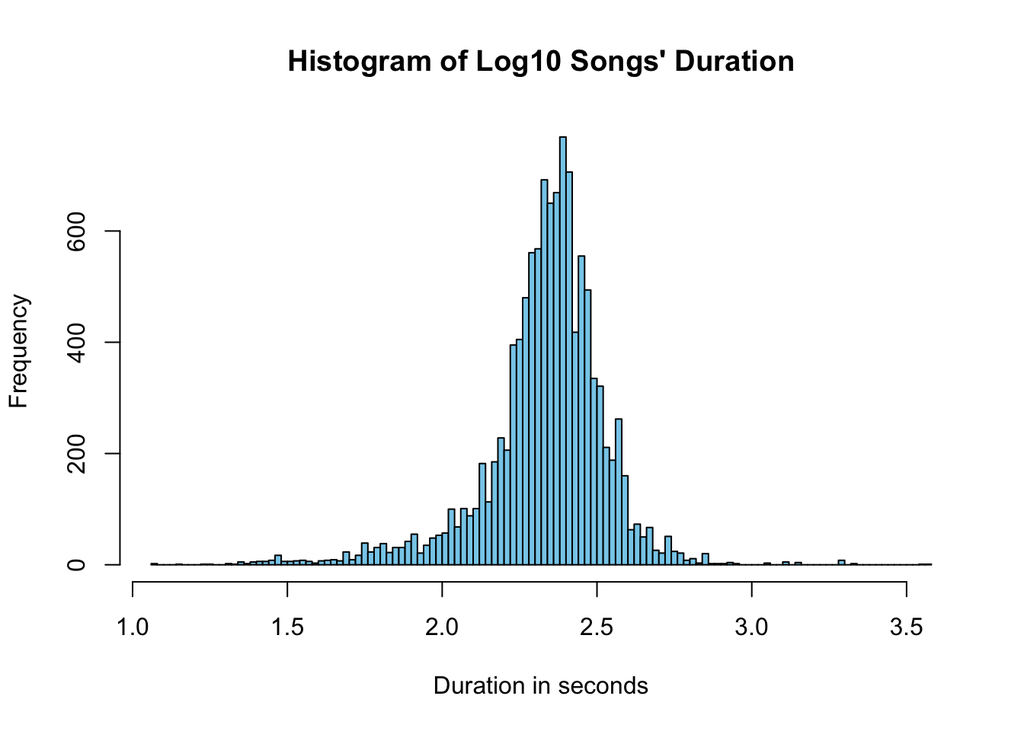

```r
songs_selected$duration_min %>% period_to_seconds() %>% log10() %>%
   hist(main="Histogram of Log10 Songs' Duration", xlab="Duration in seconds", breaks=100, col="skyblue")
```

Alternatively, we can also apply BoxCox transformation using `BoxCox()` function from `forecast` package.

```r
Boxcox_duration <- songs_selected$duration_min %>%
  period_to_seconds() %>%
  BoxCox(lambda = "auto")

head(Boxcox_duration, n = 30)
```

```
##  [1] 6.982430 6.622924 3.729695 3.729695 3.729695 3.729695 3.729695 3.729695
##  [9] 5.858932 6.486125 6.486125 6.486125 6.486125 6.486125 6.486125 6.486125
## [17] 6.486125 6.486125 6.419668 6.419668 6.419668 6.419668 8.000830 6.681304
## [25] 6.681304 6.681304 6.681304 6.433192 6.433192 6.433192
```

```r
# Showing the optimum lambda value
attr(Boxcox_duration,"lambda")
```

```
## [1] 0.06641402
```

The values returned from the function are transformed with the best parameter as we set lambda = “auto” and the optimum lambda value is found as 0.06641402. We can check the distribution of transformed values using `hist()` function.

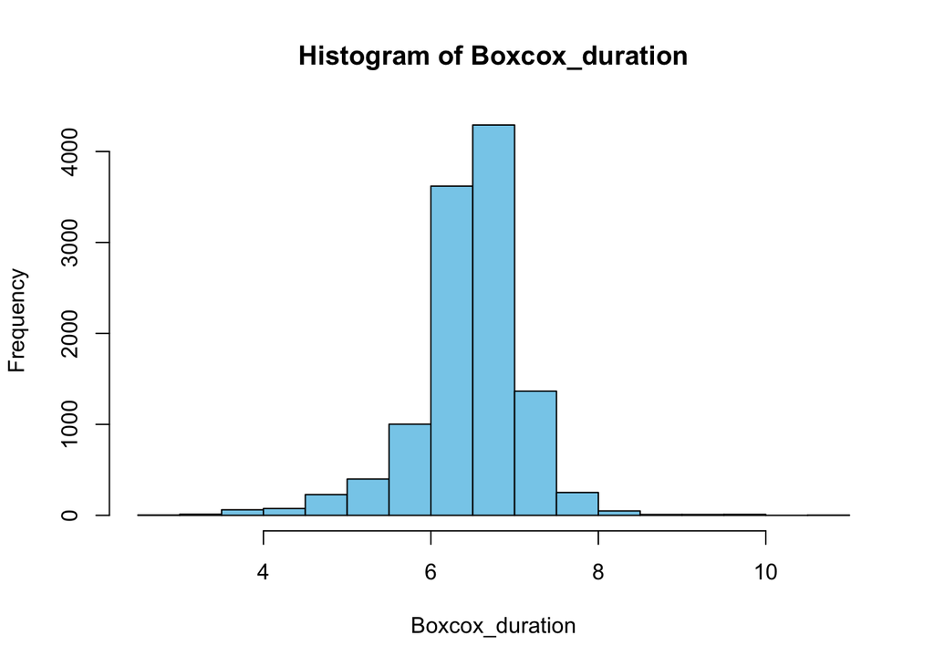

```r
# Histogram of Boxcox
hist(Boxcox_duration, col="skyblue")
```

In conclusion, through several data preprocessing techniques, including data cleaning, transformation and addressing outliers, we have successfully created a tidy dataset. The application of the Box-Cox transformation has enhanced the normality of our variables, ensuring a more robust and standardized representation. This clean dataset stands as a reliable foundation, ready for seamless integration into further analyses and statistical modeling. Its adherence to best practices and tidy data principles positions it as a valuable resource for deriving meaningful insights and drawing accurate conclusions in future endeavors.

## **References**

Box, George EP, and David R Cox. 1964. “An Analysis of Transformations.” Journal of the Royal Statistical Society. Series B (Methodological), 211–52.

Wickham, Hadley, and Garrett Grolemund. 2016. R for Data Science: Import, Tidy, Transform, Visualize, and Model Data. ” O’Reilly Media, Inc.”.

EstienneGGX, dambs0ap, & Nikita Sharma. (2022, September 4). Spotify unpopular songs (unpopular_songs.csv). Kaggle. Retrieved October 7, 2022, from https://www.kaggle.com/datasets/estienneggx/spotify-unpopular-songs?select=unpopular_songs.csv

EstienneGGX, dambs0ap, & Nikita Sharma. (2022, September 4). Spotify unpopular songs (z_genre_of_artists.csv). Kaggle. Retrieved October 7, 2022, from https://www.kaggle.com/datasets/estienneggx/spotify-unpopular-songs?select=z_genre_of_artists.csv